# IE582-Assignment 3

Deniz Sezin Ayvaz - IE582 - Fall 2018

19 November 2018

**TASK 1** **Part a**

There are 8 different gesture classes. Data includes the acceleration information, and we are going to reach velocity vectors using the data. Then we need to find position vectors using average speed.

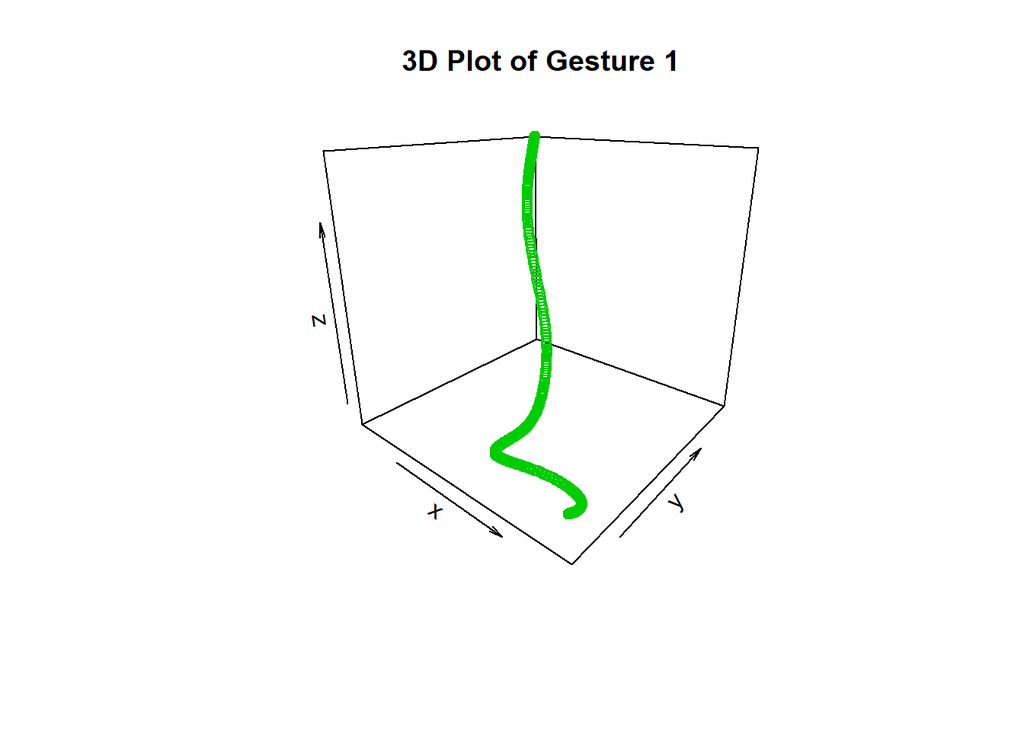

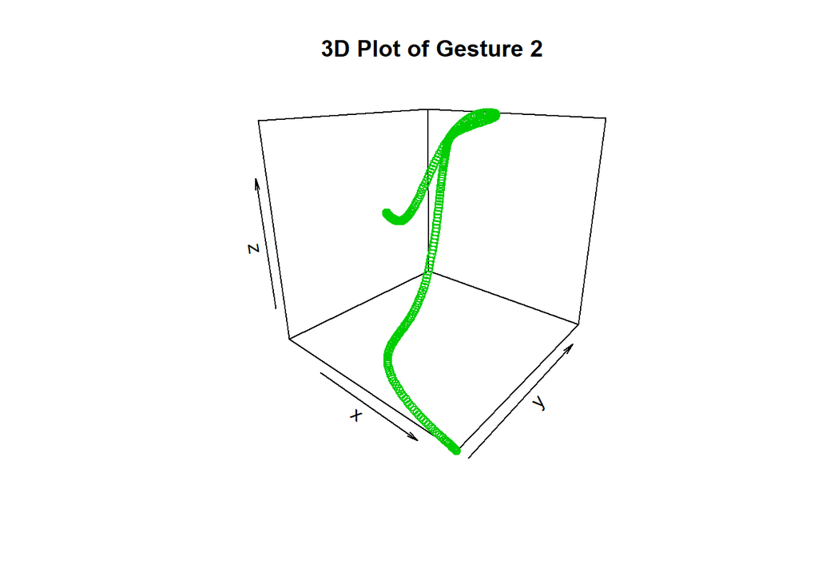

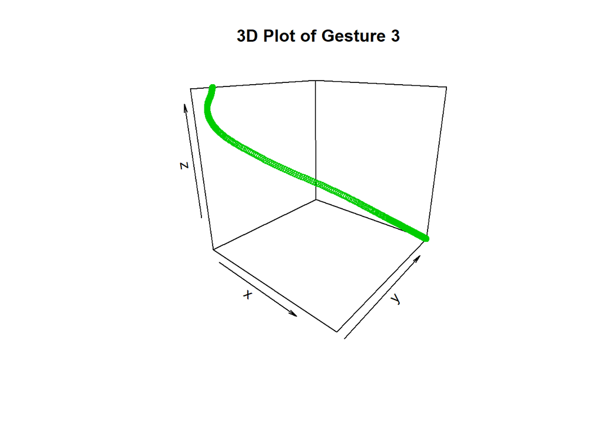

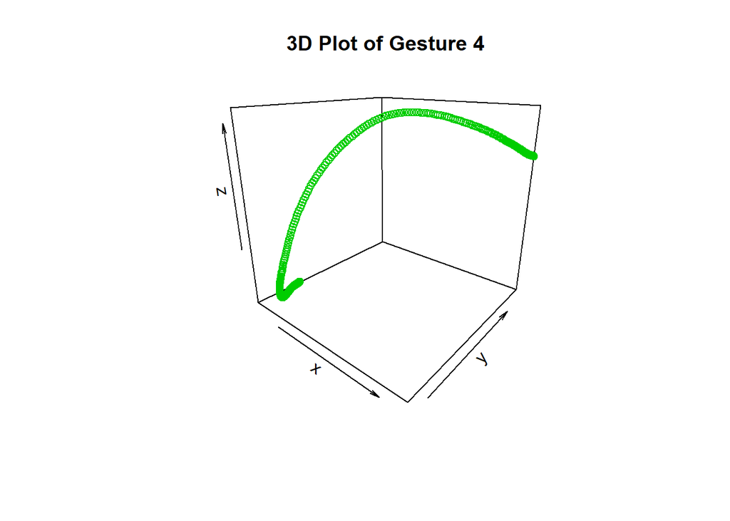

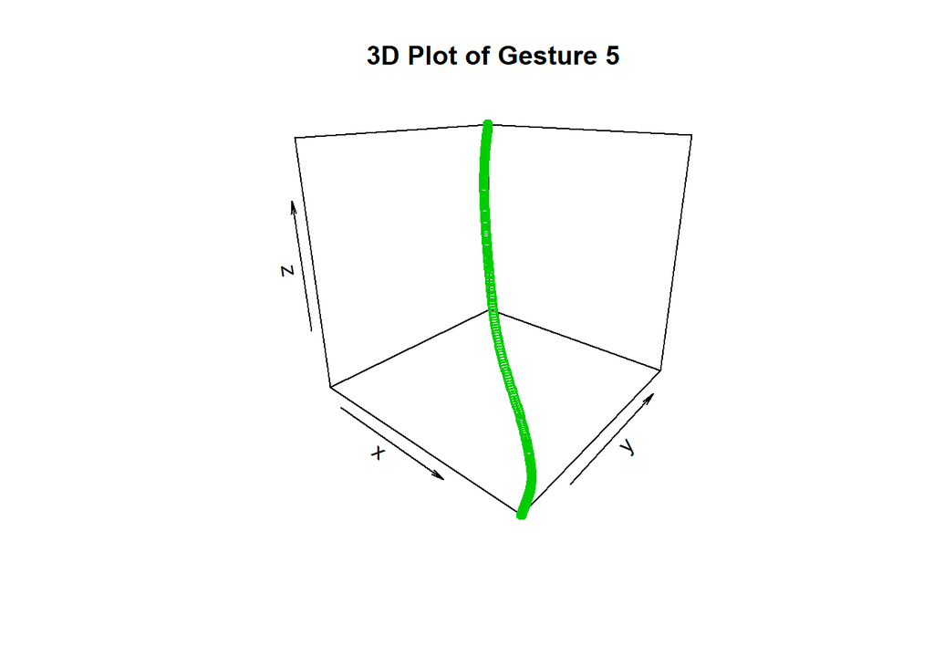

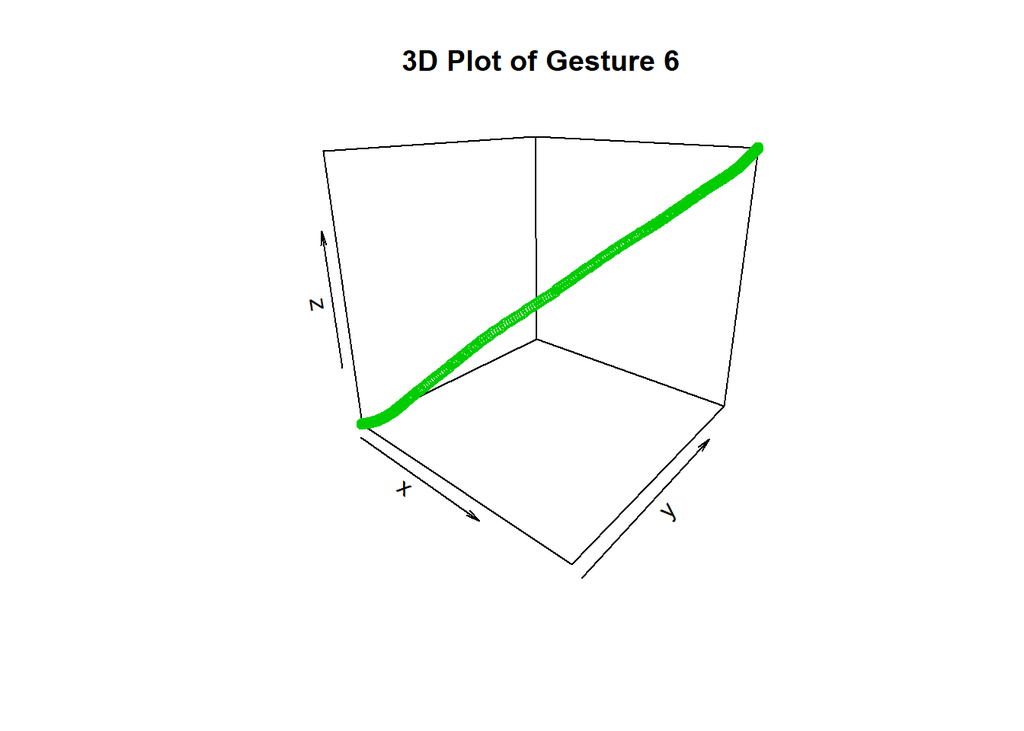

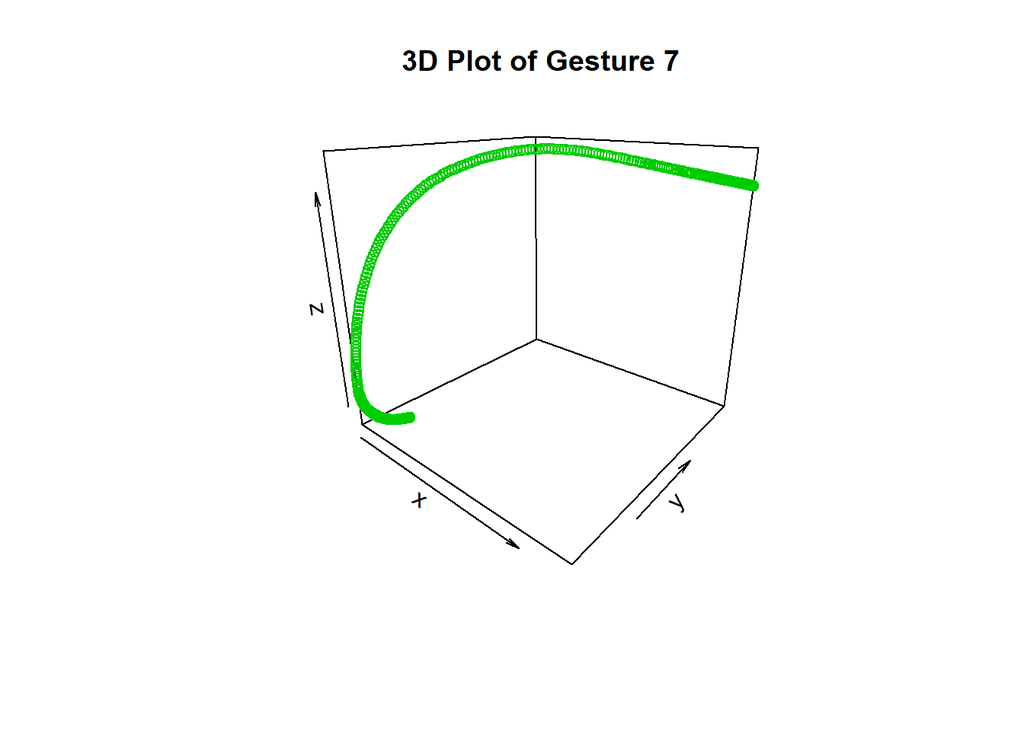

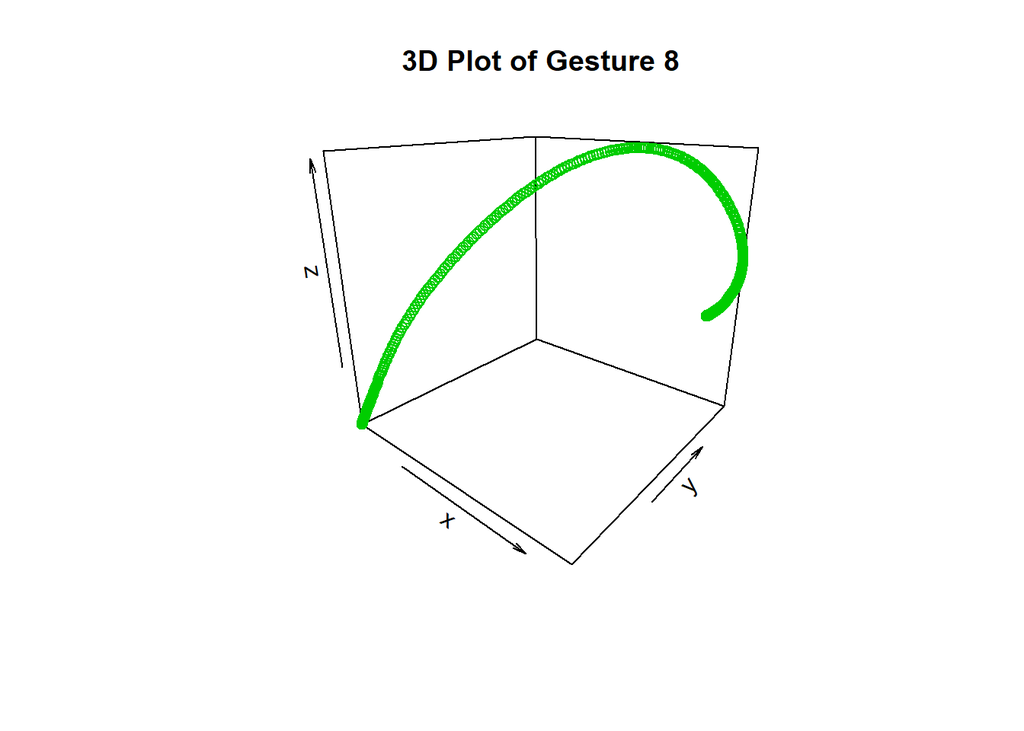

**Part b**

We can use euclidean and manhattan distance measures for computing similarity between two time series.Training data will be used to find the optimal value of k which minimizes the error for 10-fold cross-validation. The distance matrix for each measurement is generated. Then, KNN is applied to the distance matrices with different k values.

Accuracy levels for Manhattan distance is given below.It gives the best results for k= 1 and 3.

```
##    Method Klev      Accu
## 1:    knn    1 0.9564732
## 2:    knn    3 0.9564732
## 3:    knn    5 0.9542411
## 4:    knn    7 0.9475446
```

Accuracy levels for Euclidean distance is given below.It gives the best results for k=1.

```
##    Method Klev      Accu
## 1:    knn    1 0.9430804
## 2:    knn    3 0.9419643
## 3:    knn    5 0.9375000
## 4:    knn    7 0.9319196
```

**Part c** Confusion matrix, accuracy level and time required to predict for Euclidean distance is given below.

```
##           prediction_euclidean
## test_class   1   2   3   4   5   6   7   8
##          1 430   0   0   2   0   4   1   0
##          2   1 449   0   0   0   0   2   0
##          3   0   0 413   0  15  21   5   0
##          4   6   0   0 371  60   6   0   7
##          5   3   0   6   1 422   1   0   0
##          6   3   0   7  14  29 395   1   0
##          7   0   0   1   0   0   0 446   0
##          8   0   0   0   1   1   0   0 458
```

```
## [1] 0.9447236
```

```
## Time difference of 1.00629 mins
```

**TASK 2** **Part a**

Logistic regression model is tried on the training data using fused lasso penalties.Then model parameters are used to predict the classes for test data.“penalized” package is used for model generation.

```
## Welcome to penalized. For extended examples, see vignette("penalized").
```

[output not shown]

Confusion matrix and accuracy level for train data and test data are given below. Then the coefficients are plotted.

```
##           prediction_train
## trainclass  0  1
##          0 23  8
##          1  6 63
```

```
## [1] 0.86
```

```
##          prediction_test
## testclass  0  1
##         0 24 12
##         1  7 57
```

```
## [1] 0.81
```

**Part b** Some of the coefficients are forced to zero.

```
## (Intercept)
##  0.03264603 -0.19791034 -0.21415418  0.22611910  0.22611910 -0.18249458
##
## -0.18249458 -0.18249458 -0.18249458 -0.18249458 -0.18249458  0.23128890
##
##  0.23128890  0.23128890  0.23128890 -0.66956288 -0.66956288
```

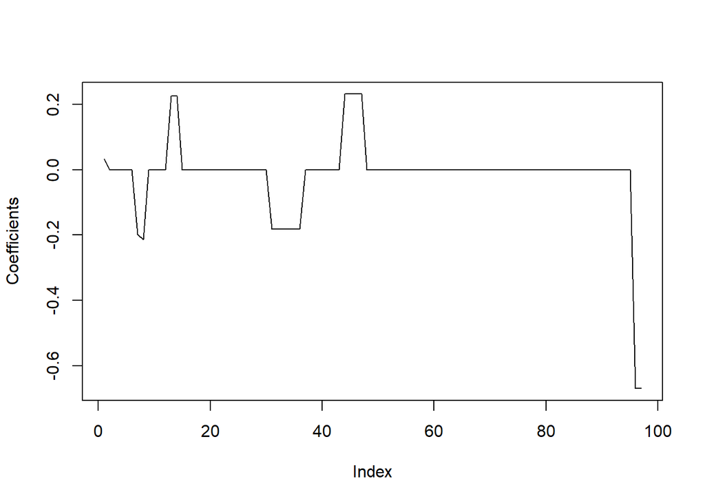

**Part c** We take the difference between consecutive time series observations to transform the time series. Then, we can apply the same procedure above.

[output not shown]

[output not shown]

```
##           prediction_train_diff
## trainclass  0  1
##          0 21 10
##          1  6 63
```

```
## [1] 0.84
```

```
##          prediction_test_diff
## testclass  0  1
##         0 26 10
##         1  5 59
```

```
## [1] 0.85
```

**Part d**

```
## (Intercept)
## -0.32551812  0.53422191  0.53422191  0.01518685 -0.08212411  0.35084976
##
##  0.35084976  0.35084976  0.35084976  0.35084976  0.85377116  0.85377116
##
##  0.85377116  0.85377116  0.85377116  0.44570905 -0.34599018 -0.34599018
```

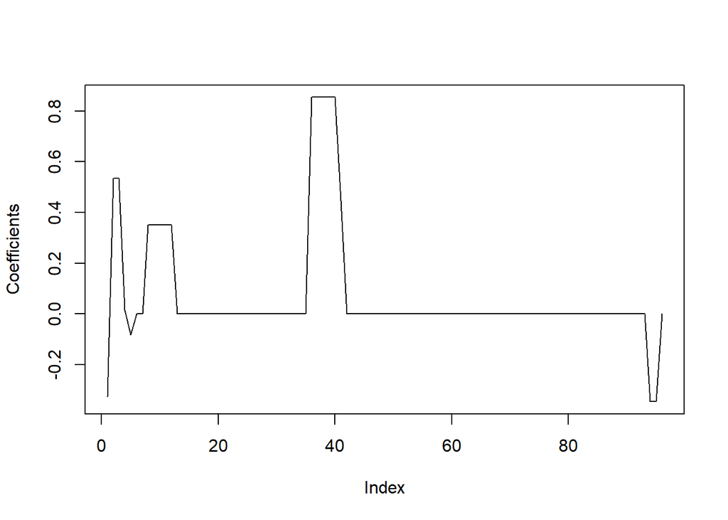

**APPENDIX**

library(TunePareto) library(plot3D) library(data.table) library(FastKNN) library(kknn) library(class) datX<-as.data.table(read.table(‘C:/Users/dsa/Desktop/582 dosyalar/uWaveGestureLibrary_X_TRAIN’)) datY<-as.data.table(read.table(‘C:/Users/dsa/Desktop/582 dosyalar/uWaveGestureLibrary_Y_TRAIN’)) datZ<-as.data.table(read.table(‘C:/Users/dsa/Desktop/582 dosyalar/uWaveGestureLibrary_Z_TRAIN’))

datX_test<-as.data.table(read.table(‘C:/Users/dsa/Desktop/582 dosyalar/uWaveGestureLibrary_X_TEST’)) datY_test<-as.data.table(read.table(‘C:/Users/dsa/Desktop/582 dosyalar/uWaveGestureLibrary_Y_TEST’)) datZ_test<-as.data.table(read.table(‘C:/Users/dsa/Desktop/582 dosyalar/uWaveGestureLibrary_Z_TEST’))

for (k in 1:8) { motion.X <- datX[datX$V1 == k, ] motion.Y <- datY[datY$V1 == k, ] motion.Z <- datZ[datZ$V1 == k, ]

acc_x<-motion.X[4,2:316] vel_x<-cumsum(as.list(acc_x)) #the ending speed in that second new.vel_x<-as.matrix(c(0,vel_x)) new.vel_x<-new.vel_x[-316,] #the starting speed in that second avg_vel_x<-(vel_x + new.vel_x)/2 #the average speed in that second position.x<-cumsum(as.list(avg_vel_x))

acc_y<-motion.Y[4,2:316] vel_y<-cumsum(as.list(acc_y)) #the ending speed in that second new.vel_y<-as.matrix(c(0,vel_y)) new.vel_y<-new.vel_y[-316,] #the starting speed in that second avg_vel_y<-(vel_y + new.vel_y)/2 #the average speed in that second position.y<-cumsum(as.list(avg_vel_y))

acc_z<-motion.Z[4,2:316] vel_z<-cumsum(as.list(acc_z)) #the ending speed in that second new.vel_z<-as.matrix(c(0,vel_z)) new.vel_z<-new.vel_z[-316,] #the starting speed in that second avg_vel_z<-(vel_z + new.vel_z)/2 #the average speed in that second position.z<-cumsum(as.list(avg_vel_z))

position.3d<-cbind(position.x,position.y,position.z) scatter3D(position.x,position.y,position.z,col=3,phi=20,main=paste0(“3D Plot of Gesture”,k))

} train_class=datX[,1]$V1 test_class=datX_test[,1]$V1

traindata_x=datX[,-1] traindata_y=datY[,-1] traindata_z=datZ[,-1] testdata_x=datX_test[,-1] testdata_y=datY_test[,-1] testdata_z=datZ_test[,-1]

traindata<-cbind(traindata_x,traindata_y,traindata_z) testdata<-cbind(testdata_x,testdata_y,testdata_z) traindata<-as.data.table(traindata) testdata<-as.data.table(testdata)

k_levels=c(1,3,5,7)

distance_manhattan = as.matrix(dist(traindata, method = “manhattan”))

nofReplications=1 nFolds=10 set.seed(125)

fold_indices=generateCVRuns(train_class,nofReplications,nFolds,stratified=TRUE)

# perform 10 fold cross validation to choose the most appropriate k-level for manhattan distance measure

cvresult=data.table() for(i in 1:nofReplications) { Replication=fold_indices[[i]] for(j in 1:nFolds){ testindices=Replication[[j]] cvtrain=traindata[-testindices,]  
cvtest=traindata[testindices,] index<-as.numeric(rownames(cvtrain))

```
for(y in 1:length(k_levels)){
  param_k=k_levels[y]
  predict_knn = knn_test_function(cvtrain, cvtest, distance_manhattan[testindices,index], train_class, k = param_k)
  cvresult=rbind(cvresult,data.table(Replication=i,Fold=j,Method='knn',Klev=param_k,TestId=testindices,
                                     Predictions=as.numeric(as.character(predict_knn)),Real=train_class[testindices]))
}
```

}  
}

# list the accuracies for different k-levels

cvresult[,list(Accu=mean(Predictions==Real)),by=list(Method,Klev)]

distance_euclidean = as.matrix(dist(traindata, method = “euclidean”))

cvresult=data.table() for(i in 1:nofReplications) { Replication=fold_indices[[i]] for(j in 1:nFolds){ testindices=Replication[[j]] cvtrain=traindata[-testindices,]  
cvtest=traindata[testindices,] index<-as.numeric(rownames(cvtrain))

```
for(y in 1:length(k_levels)){
  param_k=k_levels[y]
  predict_knn = knn_test_function(cvtrain, cvtest, distance_euclidean[testindices,index], train_class, k = param_k)
  cvresult=rbind(cvresult,data.table(Replication=i,Fold=j,Method='knn',Klev=param_k,TestId=testindices,
                                     Predictions=as.numeric(as.character(predict_knn)),Real=train_class[testindices]))
}
```

}  
}

cvresult[,list(Accu=mean(Predictions==Real)),by=list(Method,Klev)]

start_time_manhattan <- Sys.time()

distance_manhattan_test = dist(testdata,traindata,method = “manhattan”) distance_manhattan_test<-as.matrix(distance_manhattan_test)

prediction_manhattan=knn_test_function(traindata, testdata, distance_manhattan_test, train_class, k = 1)

end_time_manhattan <- Sys.time()

start.time_euclidean <- Sys.time()

prediction_euclidean=knn(traindata, testdata,train_class, k = 3)

end_time_euclidean <- Sys.time()

conf_matrix_e=table(test_class, prediction_euclidean) accuracy_euclidean<-sum(diag(conf_matrix_e))/sum(conf_matrix_e)

**TASK2**

require(penalized) require(caret)

setwd(“C:/Users/dsa/Desktop/582 Dosyalar/NN_Classification”)

fname=‘ecgTRAIN’ # data path traindata <- data.frame(read.table(fname)) fname=‘ecgTEST’ # data path testdata <- data.frame(read.table(fname))

# first column is the class variable

trainclass=traindata[,1] #takes 0 and 1 testclass=testdata[,1] #takes 0

traindata=traindata[,2:ncol(traindata)] testdata=testdata[,2:ncol(testdata)]

trainclass[(trainclass==-1)]=0

testclass[(testclass==-1)]=0

lambda1<-optL1(response=trainclass,fusedl = TRUE,penalized=traindata,model = “logistic”,fold = 10) lambda2<-optL2(response=trainclass,fusedl = TRUE,penalized=traindata,model = “logistic”,fold = 10,lambda1=lambda1$lambda)

pen_model<- penalized(trainclass, penalized = ~., data = traindata, lambda1 = lambda1$lambda, lambda2 = lambda2$lambda, model = “logistic”, fusedl = TRUE)

prediction_train<-predict(pen_model,penalized=traindata)

prediction_train[prediction_train>0.5]=1 prediction_train[prediction_train<=0.5]=0

conf_matrix_train<-table(trainclass,prediction_train) accuracy_train<-(conf_matrix_train[1,1]+conf_matrix_train[2,2])/sum(conf_matrix_train) accuracy_train

prediction_test<-predict(pen_model,penalized=testdata)

prediction_test[prediction_test>0.5]=1 prediction_test[prediction_test<=0.5]=0

conf_matrix_test<-table(testclass,prediction_test) accuracy_test<-(conf_matrix_test[1,1]+conf_matrix_test[2,2])/sum(conf_matrix_test) accuracy_test

coefficients(pen_model)

plot(coefficients(pen_model,“all”),ylab = “Coefficients”,type=“l”)

ts_test = ts(t(testdata)) ts_train = ts(t(traindata))

ts_test=as.data.frame(t(diff(ts_test))) ts_train=as.data.frame(t(diff(ts_train)))

lambda1_diff<-optL1(response=trainclass,fusedl = TRUE,penalized=ts_train,model = “logistic”,fold = 10) lambda2_diff<-optL2(trainclass, fusedl=TRUE,penalized = ts_train, lambda1 = lambda1_diff$lambda, maxlambda2 = 1, model = “logistic”, fold = 10)

pen_model_diff<- penalized(trainclass, penalized = ~., data = ts_train, lambda1 = lambda1_diff$lambda, lambda2 = lambda2_diff$lambda, model = “logistic”, fusedl = TRUE)

prediction_train_diff<-predict(pen_model_diff,penalized=ts_train)

prediction_train_diff[prediction_train_diff>0.5]=1 prediction_train_diff[prediction_train_diff<=0.5]=0

conf_matrix_train_diff<-table(trainclass,prediction_train_diff) accuracy_train_diff<-(conf_matrix_train_diff[1,1]+conf_matrix_train_diff[2,2])/sum(conf_matrix_train_diff) accuracy_train_diff

prediction_test_diff<-predict(pen_model_diff,penalized=ts_test)

prediction_test_diff[prediction_test_diff>0.5]=1 prediction_test_diff[prediction_test_diff<=0.5]=0

conf_matrix_test_diff<-table(testclass,prediction_test_diff) accuracy_test_diff<-(conf_matrix_test_diff[1,1]+conf_matrix_test_diff[2,2])/sum(conf_matrix_test_diff) accuracy_test_diff

coefficients(pen_model_diff)

plot(coefficients(pen_model_diff,“all”),ylab = “Coefficients”,type=“l”)